# Optimal Treatment Analysis

## Outcome Variable

**Outcome Variable:** ever_stunted

## Predictor Variables

**Intervention Variable:** hfoodsec

**Adjustment Set:**

- arm
- sex
- W_mage
- meducyrs
- feducyrs
- hhwealth_quart
- vagbrth
- W_nrooms
- W_nchldlt5
- brthmon
- W_parity
- impfloor
- impsan
- safeh20
- delta_W_mage
- delta_meducyrs
- delta_feducyrs
- delta_hhwealth_quart
- delta_vagbrth
- delta_W_nrooms
- delta_W_nchldlt5
- delta_brthmon
- delta_W_parity
- delta_impfloor
- delta_impsan
- delta_safeh20

## Stratifying Variables

The analysis was stratified on these variable(s):

- agecat
- studyid
- country

## Data Summary

| agecat | studyid | country | hfoodsec | ever_stunted | n_cell | n |
| --- | --- | --- | --- | --- | --- | --- |
| 0-24 months | ki0047075b-MAL-ED | BANGLADESH | Food Secure | 0 | 62 | 194 |
| 0-24 months | ki0047075b-MAL-ED | BANGLADESH | Food Secure | 1 | 99 | 194 |
| 0-24 months | ki0047075b-MAL-ED | BANGLADESH | Mildly Food Insecure | 0 | 1 | 194 |
| 0-24 months | ki0047075b-MAL-ED | BANGLADESH | Mildly Food Insecure | 1 | 3 | 194 |
| 0-24 months | ki0047075b-MAL-ED | BANGLADESH | Food Insecure | 0 | 10 | 194 |
| 0-24 months | ki0047075b-MAL-ED | BANGLADESH | Food Insecure | 1 | 19 | 194 |
| 0-24 months | ki0047075b-MAL-ED | BRAZIL | Food Secure | 0 | 3 | 129 |
| 0-24 months | ki0047075b-MAL-ED | BRAZIL | Food Secure | 1 | 0 | 129 |
| 0-24 months | ki0047075b-MAL-ED | BRAZIL | Mildly Food Insecure | 0 | 7 | 129 |
| 0-24 months | ki0047075b-MAL-ED | BRAZIL | Mildly Food Insecure | 1 | 4 | 129 |
| 0-24 months | ki0047075b-MAL-ED | BRAZIL | Food Insecure | 0 | 90 | 129 |
| 0-24 months | ki0047075b-MAL-ED | BRAZIL | Food Insecure | 1 | 25 | 129 |
| 0-24 months | ki0047075b-MAL-ED | INDIA | Food Secure | 0 | 67 | 212 |
| 0-24 months | ki0047075b-MAL-ED | INDIA | Food Secure | 1 | 123 | 212 |
| 0-24 months | ki0047075b-MAL-ED | INDIA | Mildly Food Insecure | 0 | 5 | 212 |
| 0-24 months | ki0047075b-MAL-ED | INDIA | Mildly Food Insecure | 1 | 0 | 212 |
| 0-24 months | ki0047075b-MAL-ED | INDIA | Food Insecure | 0 | 7 | 212 |
| 0-24 months | ki0047075b-MAL-ED | INDIA | Food Insecure | 1 | 10 | 212 |
| 0-24 months | ki0047075b-MAL-ED | NEPAL | Food Secure | 0 | 63 | 128 |
| 0-24 months | ki0047075b-MAL-ED | NEPAL | Food Secure | 1 | 31 | 128 |
| 0-24 months | ki0047075b-MAL-ED | NEPAL | Mildly Food Insecure | 0 | 9 | 128 |
| 0-24 months | ki0047075b-MAL-ED | NEPAL | Mildly Food Insecure | 1 | 6 | 128 |
| 0-24 months | ki0047075b-MAL-ED | NEPAL | Food Insecure | 0 | 9 | 128 |
| 0-24 months | ki0047075b-MAL-ED | NEPAL | Food Insecure | 1 | 10 | 128 |
| 0-24 months | ki0047075b-MAL-ED | PERU | Food Secure | 0 | 6 | 113 |
| 0-24 months | ki0047075b-MAL-ED | PERU | Food Secure | 1 | 21 | 113 |
| 0-24 months | ki0047075b-MAL-ED | PERU | Mildly Food Insecure | 0 | 8 | 113 |
| 0-24 months | ki0047075b-MAL-ED | PERU | Mildly Food Insecure | 1 | 21 | 113 |
| 0-24 months | ki0047075b-MAL-ED | PERU | Food Insecure | 0 | 17 | 113 |
| 0-24 months | ki0047075b-MAL-ED | PERU | Food Insecure | 1 | 40 | 113 |

[output cut: 168 more lines]

The following strata were considered:

- agecat: 0-24 months, studyid: ki0047075b-MAL-ED, country: BANGLADESH
- agecat: 0-24 months, studyid: ki0047075b-MAL-ED, country: BRAZIL
- agecat: 0-24 months, studyid: ki0047075b-MAL-ED, country: INDIA
- agecat: 0-24 months, studyid: ki0047075b-MAL-ED, country: NEPAL
- agecat: 0-24 months, studyid: ki0047075b-MAL-ED, country: PERU
- agecat: 0-24 months, studyid: ki0047075b-MAL-ED, country: SOUTH AFRICA
- agecat: 0-24 months, studyid: ki1017093-NIH-Birth, country: BANGLADESH
- agecat: 0-24 months, studyid: ki1017093c-NIH-Crypto, country: BANGLADESH
- agecat: 0-24 months, studyid: ki1113344-GMS-Nepal, country: NEPAL
- agecat: 0-24 months, studyid: kiGH5241-JiVitA-3, country: BANGLADESH
- agecat: 0-24 months, studyid: kiGH5241-JiVitA-4, country: BANGLADESH
- agecat: 0-6 months, studyid: ki0047075b-MAL-ED, country: BANGLADESH
- agecat: 0-6 months, studyid: ki0047075b-MAL-ED, country: BRAZIL
- agecat: 0-6 months, studyid: ki0047075b-MAL-ED, country: INDIA
- agecat: 0-6 months, studyid: ki0047075b-MAL-ED, country: NEPAL
- agecat: 0-6 months, studyid: ki0047075b-MAL-ED, country: PERU
- agecat: 0-6 months, studyid: ki0047075b-MAL-ED, country: SOUTH AFRICA
- agecat: 0-6 months, studyid: ki1017093-NIH-Birth, country: BANGLADESH
- agecat: 0-6 months, studyid: ki1017093c-NIH-Crypto, country: BANGLADESH
- agecat: 0-6 months, studyid: ki1113344-GMS-Nepal, country: NEPAL
- agecat: 0-6 months, studyid: kiGH5241-JiVitA-3, country: BANGLADESH
- agecat: 0-6 months, studyid: kiGH5241-JiVitA-4, country: BANGLADESH
- agecat: 6-24 months, studyid: ki0047075b-MAL-ED, country: BANGLADESH
- agecat: 6-24 months, studyid: ki0047075b-MAL-ED, country: BRAZIL
- agecat: 6-24 months, studyid: ki0047075b-MAL-ED, country: INDIA
- agecat: 6-24 months, studyid: ki0047075b-MAL-ED, country: NEPAL
- agecat: 6-24 months, studyid: ki0047075b-MAL-ED, country: PERU
- agecat: 6-24 months, studyid: ki0047075b-MAL-ED, country: SOUTH AFRICA
- agecat: 6-24 months, studyid: ki1017093-NIH-Birth, country: BANGLADESH
- agecat: 6-24 months, studyid: ki1017093c-NIH-Crypto, country: BANGLADESH
- agecat: 6-24 months, studyid: ki1113344-GMS-Nepal, country: NEPAL
- agecat: 6-24 months, studyid: kiGH5241-JiVitA-3, country: BANGLADESH
- agecat: 6-24 months, studyid: kiGH5241-JiVitA-4, country: BANGLADESH

### Dropped Strata

Some strata were dropped due to rare outcomes:

- agecat: 0-24 months, studyid: ki0047075b-MAL-ED, country: BANGLADESH
- agecat: 0-24 months, studyid: ki0047075b-MAL-ED, country: BRAZIL
- agecat: 0-24 months, studyid: ki0047075b-MAL-ED, country: INDIA
- agecat: 0-6 months, studyid: ki0047075b-MAL-ED, country: BANGLADESH
- agecat: 0-6 months, studyid: ki0047075b-MAL-ED, country: BRAZIL
- agecat: 0-6 months, studyid: ki0047075b-MAL-ED, country: INDIA
- agecat: 0-6 months, studyid: ki0047075b-MAL-ED, country: NEPAL
- agecat: 0-6 months, studyid: ki0047075b-MAL-ED, country: SOUTH AFRICA
- agecat: 6-24 months, studyid: ki0047075b-MAL-ED, country: BANGLADESH
- agecat: 6-24 months, studyid: ki0047075b-MAL-ED, country: BRAZIL
- agecat: 6-24 months, studyid: ki0047075b-MAL-ED, country: INDIA
- agecat: 6-24 months, studyid: ki0047075b-MAL-ED, country: NEPAL

## Methods Detail

We’re interested in the causal parameters $E[Y_a]$ for all values of $a \in \mathcal{A}$. These parameters represent the mean outcome if, possibly contrary to fact, we intervened to set all units to have $A=a$. Under the randomization and positivity assumptions, these are identified by the statistical parameters $\psi_a=E_W[E_{Y|A,W}(Y|A=a,W)]$. In addition, we’re interested in the mean of $Y$, $E[Y]$ under no intervention (the observed mean). We will estimate these parameters by using SuperLearner to fit the relevant likelihood factors – $E_{Y|A,W}(Y|A=a,W)$ and $p(A=a|W)$, and then updating our likelihood fit using a joint TMLE.

For unadjusted analyses ($W=\{\}$), initial likelihoods were estimated using Lrnr_glm to estimate the simple $E(Y|A)$ and Lrnr_mean to estimate $p(A)$. For adjusted analyses, a small library containing Lrnr_glmnet, Lrnr_xgboost, and Lrnr_mean was used.

# Results Detail

## Results Plots

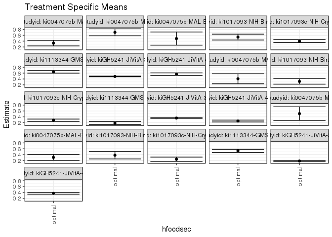

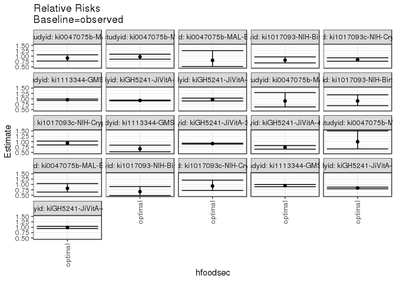

## Results Table

### Parameter: TSM

| agecat | studyid | country | intervention_level | baseline_level | estimate | ci_lower | ci_upper |
| --- | --- | --- | --- | --- | --- | --- | --- |
| 0-24 months | ki0047075b-MAL-ED | NEPAL | optimal | NA | 0.3322436 | 0.2368296 | 0.4276576 |
| 0-24 months | ki0047075b-MAL-ED | PERU | optimal | NA | 0.7013768 | 0.5820823 | 0.8206713 |
| 0-24 months | ki0047075b-MAL-ED | SOUTH AFRICA | optimal | NA | 0.4869259 | 0.2618582 | 0.7119935 |
| 0-24 months | ki1017093-NIH-Birth | BANGLADESH | optimal | NA | 0.5382807 | 0.4379298 | 0.6386315 |
| 0-24 months | ki1017093c-NIH-Crypto | BANGLADESH | optimal | NA | 0.4007099 | 0.3498049 | 0.4516149 |
| 0-24 months | ki1113344-GMS-Nepal | NEPAL | optimal | NA | 0.6432493 | 0.5994369 | 0.6870617 |
| 0-24 months | kiGH5241-JiVitA-3 | BANGLADESH | optimal | NA | 0.4855381 | 0.4734100 | 0.4976662 |
| 0-24 months | kiGH5241-JiVitA-4 | BANGLADESH | optimal | NA | 0.5657537 | 0.5232365 | 0.6082710 |
| 0-6 months | ki0047075b-MAL-ED | PERU | optimal | NA | 0.4063767 | 0.2355062 | 0.5772472 |
| 0-6 months | ki1017093-NIH-Birth | BANGLADESH | optimal | NA | 0.3163677 | 0.2228231 | 0.4099123 |
| 0-6 months | ki1017093c-NIH-Crypto | BANGLADESH | optimal | NA | 0.2819346 | 0.2405002 | 0.3233690 |
| 0-6 months | ki1113344-GMS-Nepal | NEPAL | optimal | NA | 0.1860896 | 0.1368982 | 0.2352809 |
| 0-6 months | kiGH5241-JiVitA-3 | BANGLADESH | optimal | NA | 0.3578980 | 0.3460612 | 0.3697348 |
| 0-6 months | kiGH5241-JiVitA-4 | BANGLADESH | optimal | NA | 0.2559739 | 0.2242562 | 0.2876915 |
| 6-24 months | ki0047075b-MAL-ED | PERU | optimal | NA | 0.5085515 | 0.2759493 | 0.7411537 |
| 6-24 months | ki0047075b-MAL-ED | SOUTH AFRICA | optimal | NA | 0.3055770 | 0.2038120 | 0.4073421 |
| 6-24 months | ki1017093-NIH-Birth | BANGLADESH | optimal | NA | 0.3804191 | 0.2534311 | 0.5074072 |
| 6-24 months | ki1017093c-NIH-Crypto | BANGLADESH | optimal | NA | 0.2439717 | 0.1714561 | 0.3164872 |
| 6-24 months | ki1113344-GMS-Nepal | NEPAL | optimal | NA | 0.5276983 | 0.4741313 | 0.5812653 |
| 6-24 months | kiGH5241-JiVitA-3 | BANGLADESH | optimal | NA | 0.1823192 | 0.1707685 | 0.1938698 |
| 6-24 months | kiGH5241-JiVitA-4 | BANGLADESH | optimal | NA | 0.3687329 | 0.3424589 | 0.3950069 |

### Parameter: E(Y)

| agecat | studyid | country | intervention_level | baseline_level | estimate | ci_lower | ci_upper |
| --- | --- | --- | --- | --- | --- | --- | --- |
| 0-24 months | ki0047075b-MAL-ED | NEPAL | observed | NA | 0.3674398 | 0.2836044 | 0.4512753 |
| 0-24 months | ki0047075b-MAL-ED | PERU | observed | NA | 0.7259757 | 0.6433437 | 0.8086077 |
| 0-24 months | ki0047075b-MAL-ED | SOUTH AFRICA | observed | NA | 0.6061621 | 0.5432620 | 0.6690623 |
| 0-24 months | ki1017093-NIH-Birth | BANGLADESH | observed | NA | 0.6645778 | 0.6276505 | 0.7015050 |
| 0-24 months | ki1017093c-NIH-Crypto | BANGLADESH | observed | NA | 0.4786799 | 0.4430977 | 0.5142621 |
| 0-24 months | ki1113344-GMS-Nepal | NEPAL | observed | NA | 0.6702801 | 0.6320475 | 0.7085127 |
| 0-24 months | kiGH5241-JiVitA-3 | BANGLADESH | observed | NA | 0.5241909 | 0.5146194 | 0.5337624 |
| 0-24 months | kiGH5241-JiVitA-4 | BANGLADESH | observed | NA | 0.5841341 | 0.5681392 | 0.6001289 |
| 0-6 months | ki0047075b-MAL-ED | PERU | observed | NA | 0.4511037 | 0.3589439 | 0.5432635 |
| 0-6 months | ki1017093-NIH-Birth | BANGLADESH | observed | NA | 0.3499085 | 0.3126100 | 0.3872069 |
| 0-6 months | ki1017093c-NIH-Crypto | BANGLADESH | observed | NA | 0.3022079 | 0.2694982 | 0.3349176 |
| 0-6 months | ki1113344-GMS-Nepal | NEPAL | observed | NA | 0.2796662 | 0.2434632 | 0.3158691 |
| 0-6 months | kiGH5241-JiVitA-3 | BANGLADESH | observed | NA | 0.3938826 | 0.3850689 | 0.4026964 |
| 0-6 months | kiGH5241-JiVitA-4 | BANGLADESH | observed | NA | 0.3492286 | 0.3339463 | 0.3645110 |
| 6-24 months | ki0047075b-MAL-ED | PERU | observed | NA | 0.5092410 | 0.3827429 | 0.6357391 |
| 6-24 months | ki0047075b-MAL-ED | SOUTH AFRICA | observed | NA | 0.3722816 | 0.2933199 | 0.4512433 |
| 6-24 months | ki1017093-NIH-Birth | BANGLADESH | observed | NA | 0.5736668 | 0.5214102 | 0.6259234 |
| 6-24 months | ki1017093c-NIH-Crypto | BANGLADESH | observed | NA | 0.2627857 | 0.2243945 | 0.3011770 |
| 6-24 months | ki1113344-GMS-Nepal | NEPAL | observed | NA | 0.5574777 | 0.5095982 | 0.6053572 |
| 6-24 months | kiGH5241-JiVitA-3 | BANGLADESH | observed | NA | 0.2179574 | 0.2085675 | 0.2273472 |
| 6-24 months | kiGH5241-JiVitA-4 | BANGLADESH | observed | NA | 0.3726781 | 0.3538958 | 0.3914604 |

### Parameter: RR

| agecat | studyid | country | intervention_level | baseline_level | estimate | ci_lower | ci_upper |
| --- | --- | --- | --- | --- | --- | --- | --- |
| 0-24 months | ki0047075b-MAL-ED | NEPAL | optimal | observed | 0.9042123 | 0.7720797 | 1.0589579 |
| 0-24 months | ki0047075b-MAL-ED | PERU | optimal | observed | 0.9661161 | 0.8594404 | 1.0860326 |
| 0-24 months | ki0047075b-MAL-ED | SOUTH AFRICA | optimal | observed | 0.8032931 | 0.5158000 | 1.2510270 |
| 0-24 months | ki1017093-NIH-Birth | BANGLADESH | optimal | observed | 0.8099589 | 0.6824664 | 0.9612684 |
| 0-24 months | ki1017093c-NIH-Crypto | BANGLADESH | optimal | observed | 0.8371146 | 0.7611464 | 0.9206650 |
| 0-24 months | ki1113344-GMS-Nepal | NEPAL | optimal | observed | 0.9596724 | 0.9270125 | 0.9934830 |
| 0-24 months | kiGH5241-JiVitA-3 | BANGLADESH | optimal | observed | 0.9262620 | 0.9105642 | 0.9422303 |
| 0-24 months | kiGH5241-JiVitA-4 | BANGLADESH | optimal | observed | 0.9685341 | 0.9045035 | 1.0370975 |
| 0-6 months | ki0047075b-MAL-ED | PERU | optimal | observed | 0.9008499 | 0.6266221 | 1.2950877 |
| 0-6 months | ki1017093-NIH-Birth | BANGLADESH | optimal | observed | 0.9041441 | 0.6876582 | 1.1887831 |
| 0-6 months | ki1017093c-NIH-Crypto | BANGLADESH | optimal | observed | 0.9329162 | 0.8476021 | 1.0268174 |
| 0-6 months | ki1113344-GMS-Nepal | NEPAL | optimal | observed | 0.6653989 | 0.5295482 | 0.8361008 |
| 0-6 months | kiGH5241-JiVitA-3 | BANGLADESH | optimal | observed | 0.9086413 | 0.8874141 | 0.9303762 |
| 0-6 months | kiGH5241-JiVitA-4 | BANGLADESH | optimal | observed | 0.7329693 | 0.6536610 | 0.8219000 |
| 6-24 months | ki0047075b-MAL-ED | PERU | optimal | observed | 0.9986460 | 0.6649469 | 1.4998098 |
| 6-24 months | ki0047075b-MAL-ED | SOUTH AFRICA | optimal | observed | 0.8208222 | 0.6469785 | 1.0413780 |
| 6-24 months | ki1017093-NIH-Birth | BANGLADESH | optimal | observed | 0.6631361 | 0.4867435 | 0.9034522 |
| 6-24 months | ki1017093c-NIH-Crypto | BANGLADESH | optimal | observed | 0.9284053 | 0.7183768 | 1.1998388 |
| 6-24 months | ki1113344-GMS-Nepal | NEPAL | optimal | observed | 0.9465819 | 0.8982719 | 0.9974902 |
| 6-24 months | kiGH5241-JiVitA-3 | BANGLADESH | optimal | observed | 0.8364901 | 0.7989014 | 0.8758473 |
| 6-24 months | kiGH5241-JiVitA-4 | BANGLADESH | optimal | observed | 0.9894140 | 0.9405642 | 1.0408009 |